# Model fitting

# From the normal quantile-quantile plot and kernel densities distribution plot, we can see that random effect's performance is better

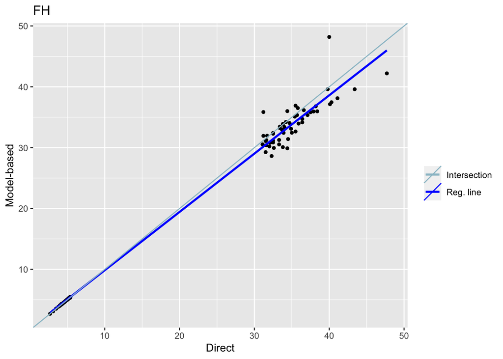

```
## Press [enter] to continue
```

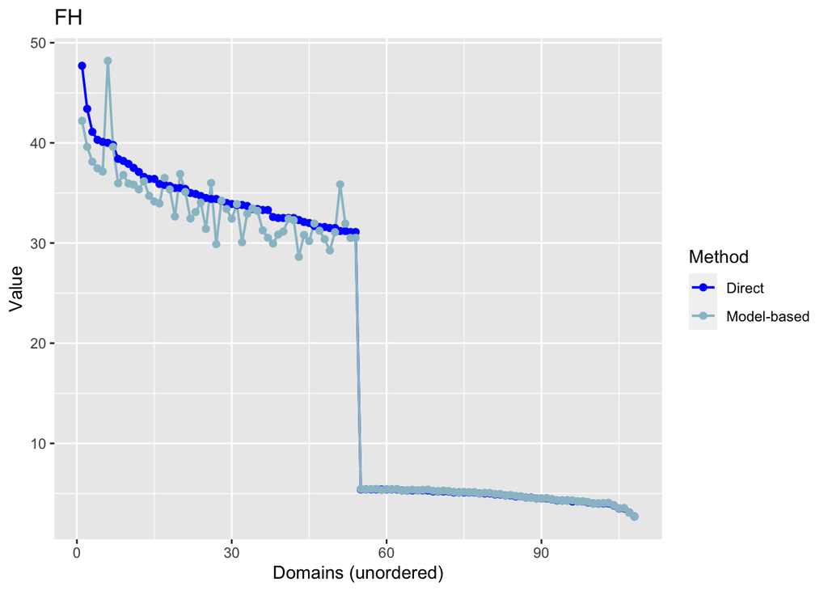

```r
#compare plot
compare_plot(fh_std)
```

```r
#compare
compare(fh_std)
```

```
## Brown test
##
## Null hypothesis: EBLUP estimates do not differ significantly from the
##       direct estimates
##
##   W.value  Df p.value
##  7.004848 108       1
##
## Correlation between synthetic part and direct estimator:  0.78
```

```r
# Extract Results
head(estimators(fh_std, CV = TRUE))
```

```
##                      Domain Direct Direct_CV       FH     FH_CV
## 1       Ziebach County (SD)   47.7 0.1185219 42.20304 0.1145994
## 2          Todd County (SD)   43.4 0.1078537 39.59805 0.1056699
## 3       Madison Parish (LA)   41.1 0.1242429 38.11850 0.1175600
## 4        Corson County (SD)   40.3 0.1161502 37.45873 0.1117410
## 5 Oglala Lakota County (SD)   40.1 0.1288572 37.13784 0.1217278
## 6       Crowley County (CO)   40.0 0.1686930 48.18985 0.1274834
```

```r
# Fit fh model with "amrl" method
fh_std2 <- fh(fixed = All.Ages.in.Poverty.Percent ~ caserate + deathrate + total_population, vardir = "var_dir", combined_data = d1, domains = "State...County.Name", method = "amrl", MSE = TRUE)
summary(fh_std2)
```

```
## Call:
##  fh(fixed = All.Ages.in.Poverty.Percent ~ caserate + deathrate +
##     total_population, vardir = "var_dir", combined_data = d1,
##     domains = "State...County.Name", method = "amrl", MSE = TRUE)
##
## Out-of-sample domains:  0
## In-sample domains:  108
##
## Variance and MSE estimation:
## Variance estimation method:  amrl
## Estimated variance component(s):  84.78418
## MSE method:  li-lahiri
##
## Coefficients:
##                   coefficients    std.error    t.value      p.value
## (Intercept)       2.334802e+00 2.775770e+00  0.8411367 4.002713e-01
## caserate          8.423043e+01 1.441621e+01  5.8427590 5.134327e-09
## deathrate         6.012615e+02 9.219667e+01  6.5215096 6.960325e-11
## total_population -4.065254e-05 7.507830e-06 -5.4146859 6.139638e-08
##
## Explanatory measures:
##     loglike      AIC     AICc    AICb1    AICb2      BIC      KIC   KICc
## 1 -396.5858 803.1715 805.9895 801.0309 803.7097 816.5822 808.1715 816.92
##      KICb1    KICb2        R2     AdjR2
## 1 811.9614 814.6402 0.5995375 0.6267393
##
## Residual diagnostics:
##                           Skewness Kurtosis Shapiro_W    Shapiro_p
## Standardized_Residuals -0.10895324 5.889426 0.8659779 1.915330e-08
## Random_effects         -0.01815022 2.196594 0.9856145 2.991866e-01
##
## Transformation: No transformation
```

# From the above p-value, we can tell that all auxiliary information are significant and death rate is still the most important auxiliary variable in this case.

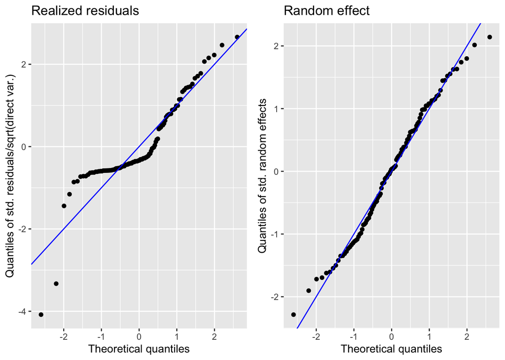

```
## Press [enter] to continue
```

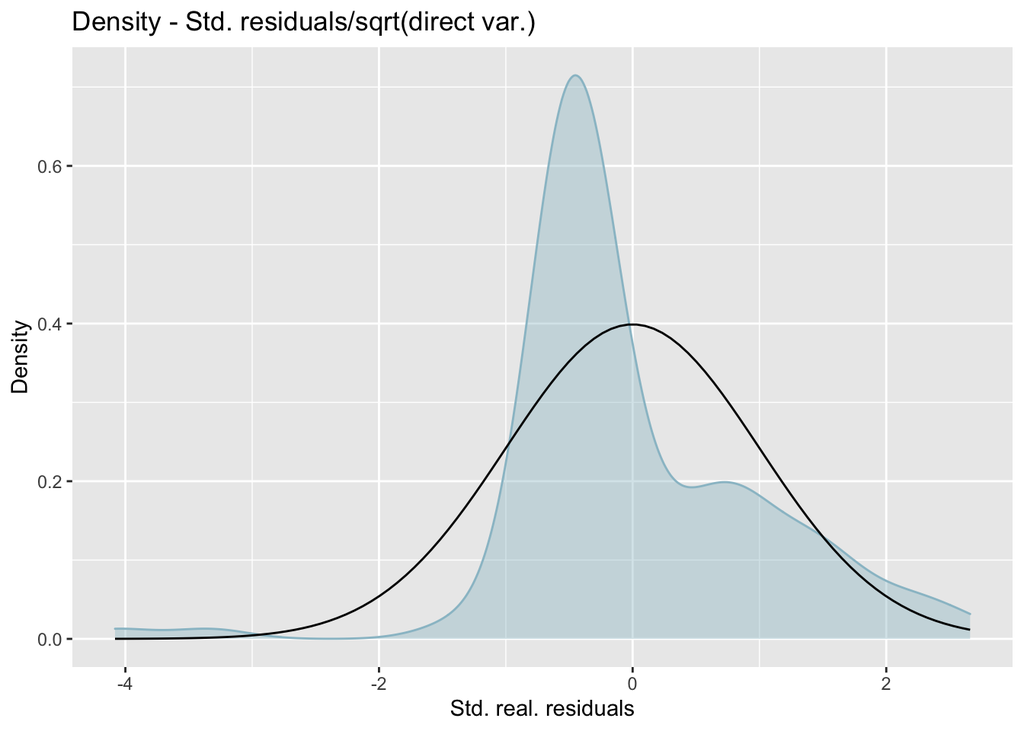

```
## Press [enter] to continue
```

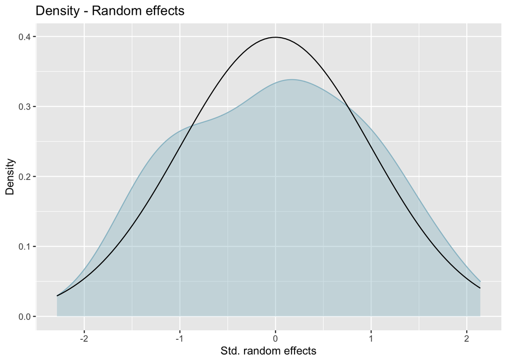

```r
# Plot
plot(fh_std2)
```

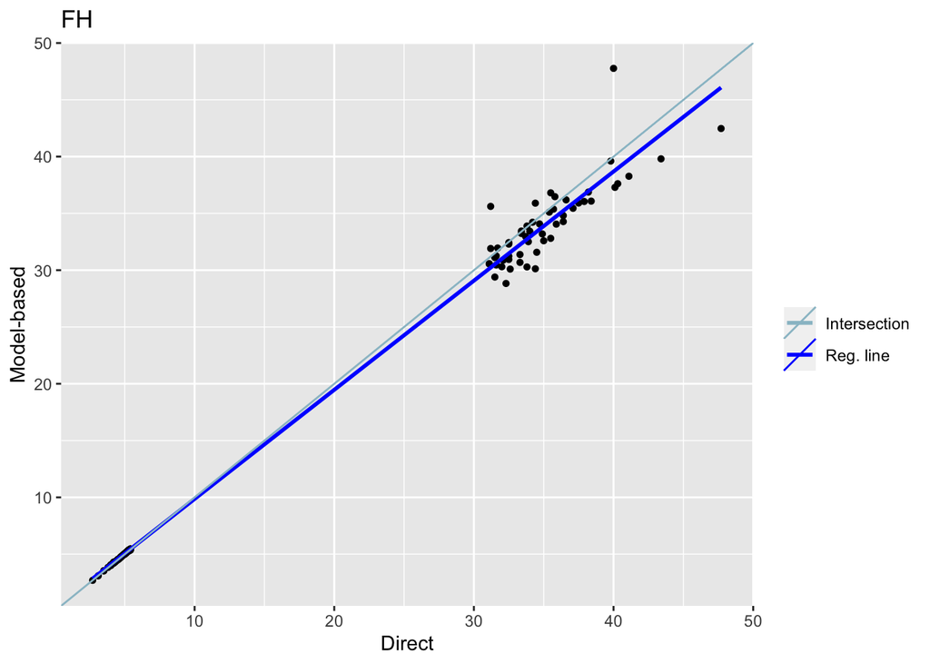

```
## Press [enter] to continue
```

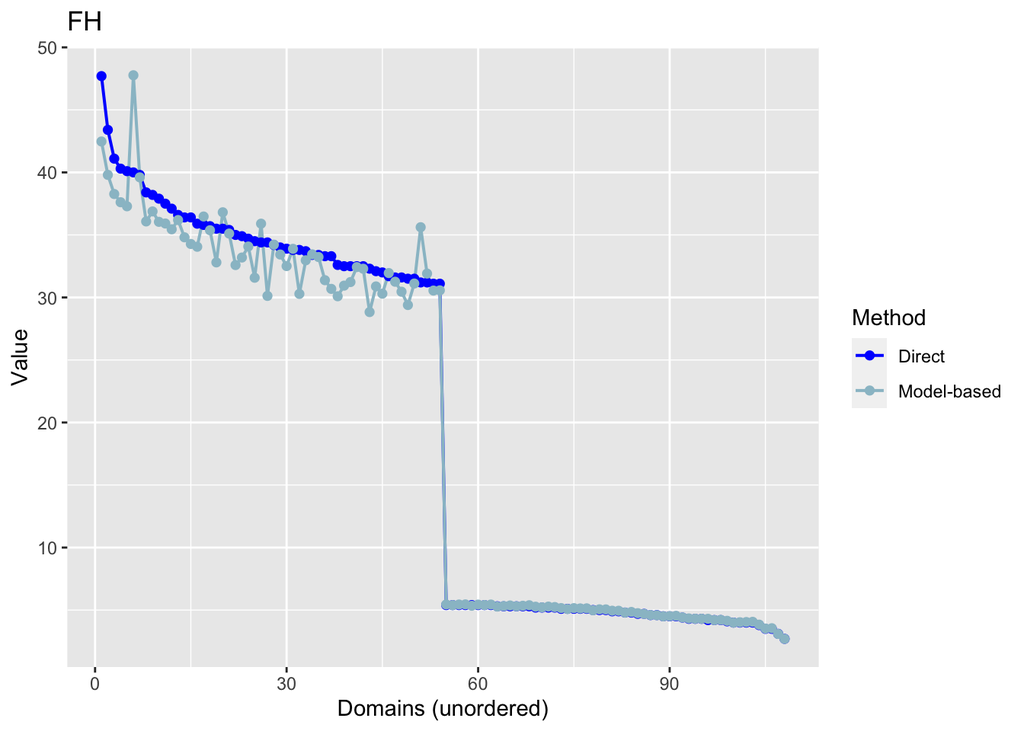

```r
#compare plot
compare_plot(fh_std2)
```

```r
#compare
compare(fh_std2)
```

```
## Brown test
##
## Null hypothesis: EBLUP estimates do not differ significantly from the
##       direct estimates
##
##   W.value  Df p.value
##  6.267527 108       1
##
## Correlation between synthetic part and direct estimator:  0.78
```

```r
# Extract Results for "amrl" method
head(estimators(fh_std2, CV = TRUE))
```

```
##                      Domain Direct Direct_CV       FH     FH_CV
## 1       Ziebach County (SD)   47.7 0.1185219 42.47265 0.1139149
## 2          Todd County (SD)   43.4 0.1078537 39.80240 0.1051509
## 3       Madison Parish (LA)   41.1 0.1242429 38.27109 0.1171227
## 4        Corson County (SD)   40.3 0.1161502 37.61424 0.1113020
## 5 Oglala Lakota County (SD)   40.1 0.1288572 37.29057 0.1212651
## 6       Crowley County (CO)   40.0 0.1686930 47.76818 0.1281921
```

```r
# Fit fh model with "reblup" method
fh_std3 <- fh(fixed = All.Ages.in.Poverty.Percent ~ caserate + deathrate + total_population, vardir = "var_dir", combined_data = d1, domains = "State...County.Name", method = "reblup", k = 1.345, c = 1, MSE = TRUE, mse_type = "boot")
summary(fh_std3)
```

```
## Call:
##  fh(fixed = All.Ages.in.Poverty.Percent ~ caserate + deathrate +
##     total_population, vardir = "var_dir", combined_data = d1,
##     domains = "State...County.Name", method = "reblup", k = 1.345,
##     c = 1, MSE = TRUE, mse_type = "boot")
##
## Out-of-sample domains:  0
## In-sample domains:  108
##
## Variance and MSE estimation:
## Variance estimation method: robustified ml, reblup
## k =  1.345
## Estimated variance component(s):  91.03479
## MSE method:  bootstrap
##
## Coefficients:
##                   coefficients
## (Intercept)       1.810245e-01
## caserate          9.435232e+01
## deathrate         6.479481e+02
## total_population -3.886203e-05
##
## Explanatory measures:
## No explanatory measures provided
##
## Residual diagnostics:
##                           Skewness Kurtosis Shapiro_W    Shapiro_p
## Standardized_Residuals  0.06796551 4.935151 0.8806257 8.000615e-08
## Random_effects         -0.04058628 2.533226 0.9924560 8.188963e-01
##
## Transformation: No transformation
```

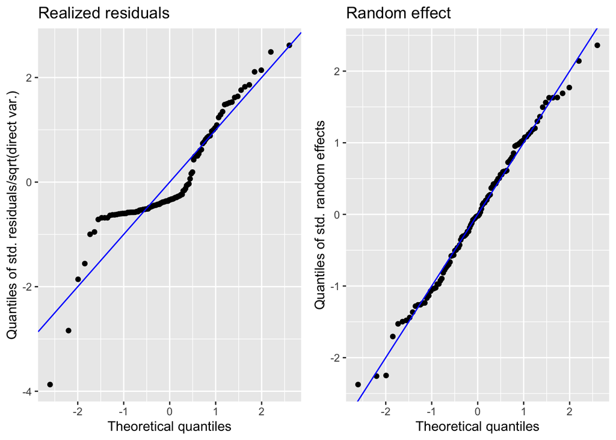

```
## Press [enter] to continue
```

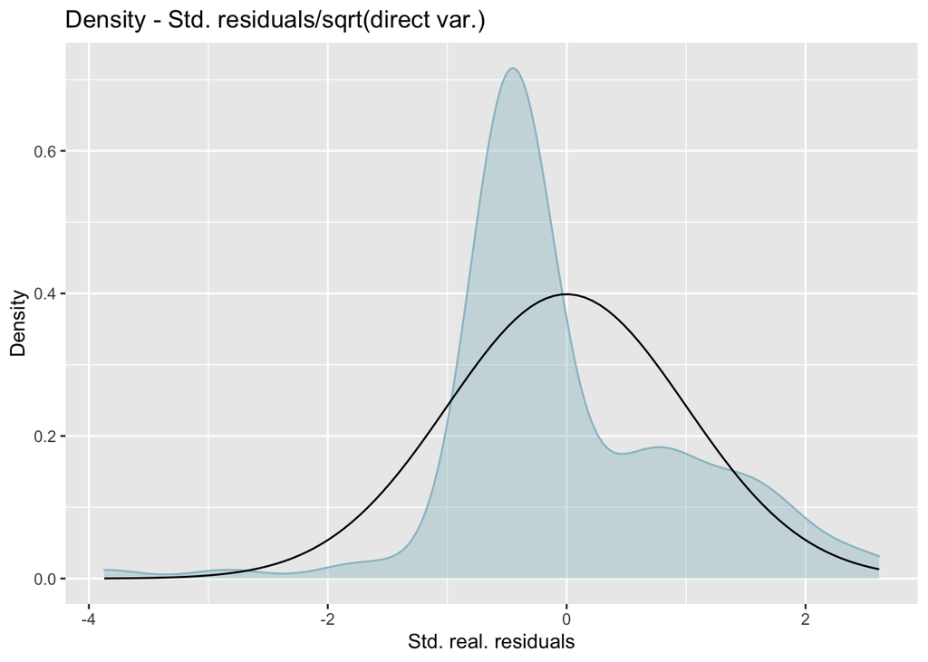

```
## Press [enter] to continue
```

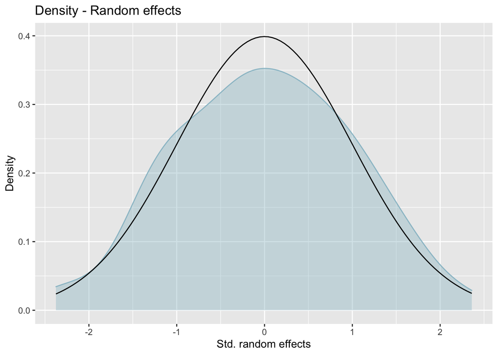

```r
# Plot
plot(fh_std3)
```

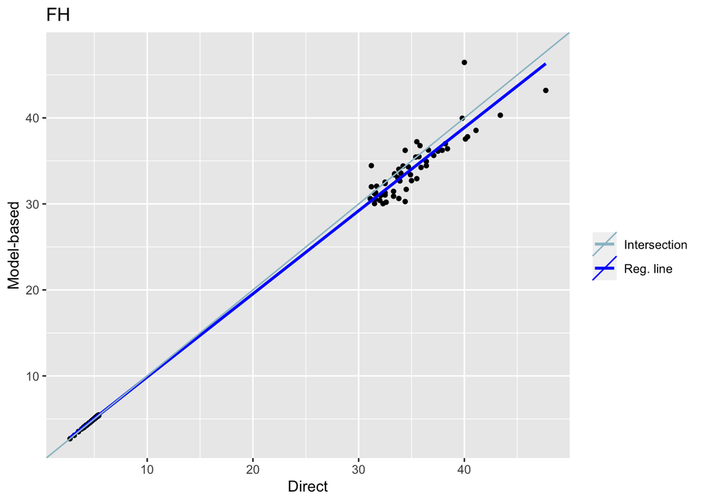

```
## Press [enter] to continue
```

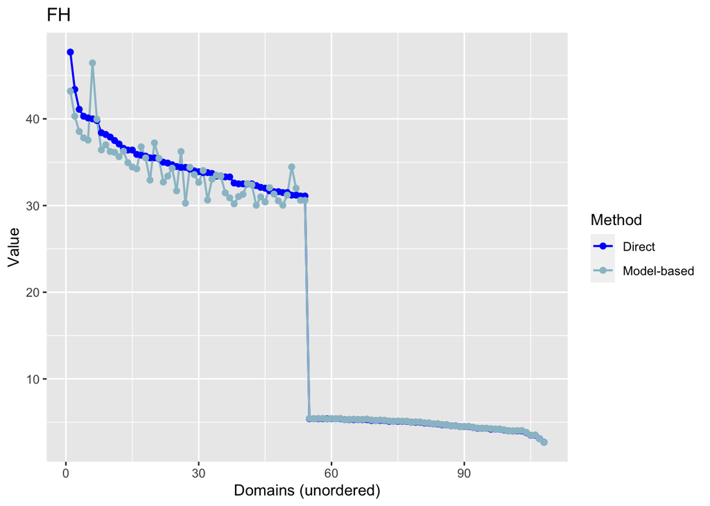

```r
#compare plot
compare_plot(fh_std3)
```

```r
#compare
compare(fh_std3)
```

```
## Brown test
##
## Null hypothesis: EBLUP estimates do not differ significantly from the
##       direct estimates
##
##   W.value  Df p.value
##  4.735137 108       1
##
## Correlation between synthetic part and direct estimator:  0.78
```

```r
# Extract Results for "reblup" method
head(estimators(fh_std3, CV = TRUE))
```

```
##                      Domain Direct Direct_CV       FH     FH_CV
## 1       Ziebach County (SD)   47.7 0.1185219 43.19405 0.1152770
## 2          Todd County (SD)   43.4 0.1078537 40.31130 0.1056805
## 3       Madison Parish (LA)   41.1 0.1242429 38.54740 0.1184500
## 4        Corson County (SD)   40.3 0.1161502 37.80439 0.1122692
## 5 Oglala Lakota County (SD)   40.1 0.1288572 37.54448 0.1315394
## 6       Crowley County (CO)   40.0 0.1686930 46.44963 0.1449780
```

# Interpretation and Conclusion

# Through fitting the combined data into fh model via three different methods, we can see that COVID-19 death rate is the most significant auxiliary variable among the others. According to the output plots, the random effects fit well, but the realized residuals' performence was not very ideal. Hypothetically speaking, it could be the reason that we did not count "n" when calculating the variance for our direct estimators. Therefore, in the future studies, we hope that we could apply a different distribution for our model.